# lab 7

Aisha Lakshman

3/3/2022

### Packages

```r
library(tidyverse)
library(broom)
library(pROC)
```

```r
library(plotROC)
library(knitr)
```

### Part I: Data Prep and Modeling

# Exercise 1

```r
spotify <- read_csv("spotify.csv")
```

```
## * `` -> ...1
```

```r
glimpse(spotify)
```

```
## Rows: 2,017
## Columns: 17
## $ ...1             <dbl> 0, 1, 2, 3, 4, 5, 6, 7, 8, 9, 10, 11, 12, 13, 14, 15,…
## $ acousticness     <dbl> 0.010200, 0.199000, 0.034400, 0.604000, 0.180000, 0.0…
## $ danceability     <dbl> 0.833, 0.743, 0.838, 0.494, 0.678, 0.804, 0.739, 0.26…
## $ duration_ms      <dbl> 204600, 326933, 185707, 199413, 392893, 251333, 24140…
## $ energy           <dbl> 0.434, 0.359, 0.412, 0.338, 0.561, 0.560, 0.472, 0.34…
## $ instrumentalness <dbl> 2.19e-02, 6.11e-03, 2.34e-04, 5.10e-01, 5.12e-01, 0.0…
## $ key              <dbl> 2, 1, 2, 5, 5, 8, 1, 10, 11, 7, 5, 10, 0, 0, 9, 6, 1,…
## $ liveness         <dbl> 0.1650, 0.1370, 0.1590, 0.0922, 0.4390, 0.1640, 0.207…
## $ loudness         <dbl> -8.795, -10.401, -7.148, -15.236, -11.648, -6.682, -1…
## $ mode             <dbl> 1, 1, 1, 1, 0, 1, 1, 0, 0, 1, 0, 1, 1, 1, 0, 1, 1, 0,…
## $ speechiness      <dbl> 0.4310, 0.0794, 0.2890, 0.0261, 0.0694, 0.1850, 0.156…
## $ tempo            <dbl> 150.062, 160.083, 75.044, 86.468, 174.004, 85.023, 80…
## $ time_signature   <dbl> 4, 4, 4, 4, 4, 4, 4, 4, 4, 4, 3, 4, 4, 4, 4, 4, 4, 4,…
## $ valence          <dbl> 0.286, 0.588, 0.173, 0.230, 0.904, 0.264, 0.308, 0.39…
## $ target           <dbl> 1, 1, 1, 1, 1, 1, 1, 1, 1, 1, 1, 1, 1, 1, 1, 1, 1, 1,…
## $ song_title       <chr> "Mask Off", "Redbone", "Xanny Family", "Master Of Non…
## $ artist           <chr> "Future", "Childish Gambino", "Future", "Beach House"…
```

```r
spotify <- spotify %>%
  drop_na() %>%
  mutate(target = as.factor(target),
         key = case_when(
           key == 2 ~ "D",
           key == 3 ~ "D#",
           TRUE ~ "Other"))

glimpse(spotify)
```

```
## Rows: 2,017
## Columns: 17
## $ ...1             <dbl> 0, 1, 2, 3, 4, 5, 6, 7, 8, 9, 10, 11, 12, 13, 14, 15,…
## $ acousticness     <dbl> 0.010200, 0.199000, 0.034400, 0.604000, 0.180000, 0.0…
## $ danceability     <dbl> 0.833, 0.743, 0.838, 0.494, 0.678, 0.804, 0.739, 0.26…
## $ duration_ms      <dbl> 204600, 326933, 185707, 199413, 392893, 251333, 24140…
## $ energy           <dbl> 0.434, 0.359, 0.412, 0.338, 0.561, 0.560, 0.472, 0.34…
## $ instrumentalness <dbl> 2.19e-02, 6.11e-03, 2.34e-04, 5.10e-01, 5.12e-01, 0.0…
## $ key              <chr> "D", "Other", "D", "Other", "Other", "Other", "Other"…
## $ liveness         <dbl> 0.1650, 0.1370, 0.1590, 0.0922, 0.4390, 0.1640, 0.207…
## $ loudness         <dbl> -8.795, -10.401, -7.148, -15.236, -11.648, -6.682, -1…
## $ mode             <dbl> 1, 1, 1, 1, 0, 1, 1, 0, 0, 1, 0, 1, 1, 1, 0, 1, 1, 0,…
## $ speechiness      <dbl> 0.4310, 0.0794, 0.2890, 0.0261, 0.0694, 0.1850, 0.156…
## $ tempo            <dbl> 150.062, 160.083, 75.044, 86.468, 174.004, 85.023, 80…
## $ time_signature   <dbl> 4, 4, 4, 4, 4, 4, 4, 4, 4, 4, 3, 4, 4, 4, 4, 4, 4, 4,…
## $ valence          <dbl> 0.286, 0.588, 0.173, 0.230, 0.904, 0.264, 0.308, 0.39…
## $ target           <fct> 1, 1, 1, 1, 1, 1, 1, 1, 1, 1, 1, 1, 1, 1, 1, 1, 1, 1,…
## $ song_title       <chr> "Mask Off", "Redbone", "Xanny Family", "Master Of Non…
## $ artist           <chr> "Future", "Childish Gambino", "Future", "Beach House"…
```

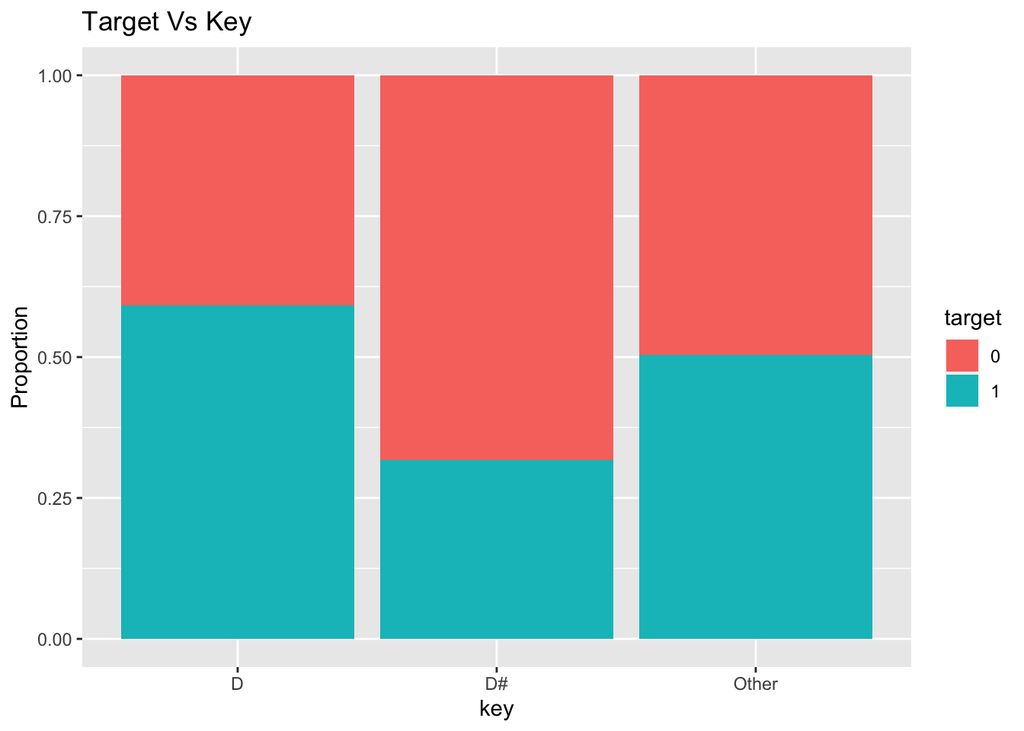

```r
ggplot(data = spotify, aes(x = key, fill = target)) +
  geom_bar(position = "fill") +
  labs(y = "Proportion", title = "Target Vs Key")
```

The figure above plots the relationship between target and key. About 60% of key D songs have a target value of 1. About 30% of key D# songs have a target value of 1. 50% of key “Other” songs have a target value of 1.

# Exercise 2

```r
model <- glm(target ~ acousticness + danceability + duration_ms + instrumentalness + loudness + speechiness + valence, data = spotify, family = binomial)

tidy(model, conf.int = TRUE, exponentiate = FALSE) %>%
  kable(format="markdown", digits = 5)
```

| term | estimate | std.error | statistic | p.value | conf.low | conf.high |
| --- | --- | --- | --- | --- | --- | --- |
| (Intercept) | -2.95548 | 0.27640 | -10.69288 | 0.00000 | -3.50377 | -2.41978 |
| acousticness | -1.72231 | 0.23982 | -7.18155 | 0.00000 | -2.19743 | -1.25678 |
| danceability | 1.63040 | 0.34421 | 4.73664 | 0.00000 | 0.95847 | 2.30841 |
| duration_ms | 0.00000 | 0.00000 | 4.22500 | 0.00002 | 0.00000 | 0.00000 |
| instrumentalness | 1.35291 | 0.20659 | 6.54883 | 0.00000 | 0.95236 | 1.76298 |
| loudness | -0.08744 | 0.01727 | -5.06219 | 0.00000 | -0.12160 | -0.05383 |
| speechiness | 4.07238 | 0.58302 | 6.98493 | 0.00000 | 2.94695 | 5.23420 |
| valence | 0.85638 | 0.22326 | 3.83573 | 0.00013 | 0.41997 | 1.29551 |

# Exercise 3

```r
model_key <- glm(target ~ acousticness + danceability + duration_ms + instrumentalness + loudness + speechiness + valence + key, data = spotify, family = binomial)

summary(model_key)$aic
```

```
## [1] 2525.16
```

```r
summary(model)$aic
```

```
## [1] 2534.517
```

By comparing the AIC values for the models with key and without key, we can see that the model with key has a lower AIC value. It is best for a model to have a low AIC value, so working with “model_key” is the right way to go.

# Exercise 4

```r
tidy(model_key, conf.int = TRUE, exponentiate = FALSE) %>%
  kable(format="markdown", digits = 5)
```

| term | estimate | std.error | statistic | p.value | conf.low | conf.high |
| --- | --- | --- | --- | --- | --- | --- |
| (Intercept) | -2.50934 | 0.31102 | -8.06817 | 0.00000 | -3.12416 | -1.90422 |
| acousticness | -1.70210 | 0.24091 | -7.06521 | 0.00000 | -2.17930 | -1.23436 |
| danceability | 1.64880 | 0.34536 | 4.77417 | 0.00000 | 0.97468 | 2.32911 |
| duration_ms | 0.00000 | 0.00000 | 4.18744 | 0.00003 | 0.00000 | 0.00000 |
| instrumentalness | 1.38316 | 0.20745 | 6.66741 | 0.00000 | 0.98104 | 1.79505 |
| loudness | -0.08662 | 0.01726 | -5.01848 | 0.00000 | -0.12075 | -0.05301 |
| speechiness | 4.03380 | 0.58491 | 6.89650 | 0.00000 | 2.90456 | 5.19917 |
| valence | 0.88094 | 0.22434 | 3.92682 | 0.00009 | 0.44248 | 1.32224 |
| keyD# | -1.07319 | 0.33497 | -3.20385 | 0.00136 | -1.74517 | -0.42805 |
| keyOther | -0.49390 | 0.16898 | -2.92288 | 0.00347 | -0.82793 | -0.16468 |

For observations of key D# the value for target with increase by e^-1.07319.

### Part II: Checking Assumptions

# Exercise 5

```r
final_model <- augment(model_key, type.predict = "response", type.residuals = "deviance")

glimpse(final_model)
```

```
## Rows: 2,017
## Columns: 15
## $ target           <fct> 1, 1, 1, 1, 1, 1, 1, 1, 1, 1, 1, 1, 1, 1, 1, 1, 1, 1,…
## $ acousticness     <dbl> 0.010200, 0.199000, 0.034400, 0.604000, 0.180000, 0.0…
## $ danceability     <dbl> 0.833, 0.743, 0.838, 0.494, 0.678, 0.804, 0.739, 0.26…
## $ duration_ms      <dbl> 204600, 326933, 185707, 199413, 392893, 251333, 24140…
## $ instrumentalness <dbl> 2.19e-02, 6.11e-03, 2.34e-04, 5.10e-01, 5.12e-01, 0.0…
## $ loudness         <dbl> -8.795, -10.401, -7.148, -15.236, -11.648, -6.682, -1…
## $ speechiness      <dbl> 0.4310, 0.0794, 0.2890, 0.0261, 0.0694, 0.1850, 0.156…
## $ valence          <dbl> 0.286, 0.588, 0.173, 0.230, 0.904, 0.264, 0.308, 0.39…
## $ key              <chr> "D", "Other", "D", "Other", "Other", "Other", "Other"…
## $ .fitted          <dbl> 0.9015924, 0.6379788, 0.7829667, 0.4223972, 0.8489462…
## $ .resid           <dbl> 0.4551764, 0.9481036, 0.6995214, 1.3128664, 0.5722926…
## $ .std.resid       <dbl> 0.4567745, 0.9493120, 0.7028629, 1.3163187, 0.5733889…
## $ .hat             <dbl> 0.006985200, 0.002544191, 0.009485687, 0.005238444, 0…
## $ .sigma           <dbl> 1.117466, 1.117311, 1.117402, 1.117126, 1.117439, 1.1…
## $ .cooksd          <dbl> 7.731894e-05, 1.451076e-04, 2.679972e-04, 7.238900e-0…
```

# Exercise 6

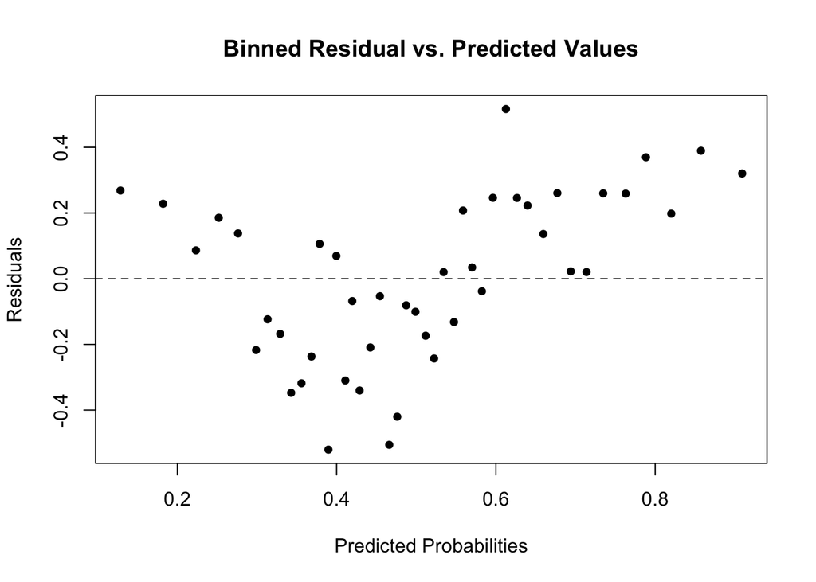

```r
arm::binnedplot(x = final_model$.fitted, y = final_model$.resid,
                xlab = "Predicted Probabilities",
                ylab = "Residuals",
                main = "Binned Residual vs. Predicted Values",
                col.int = FALSE)
```

# Exercise 7

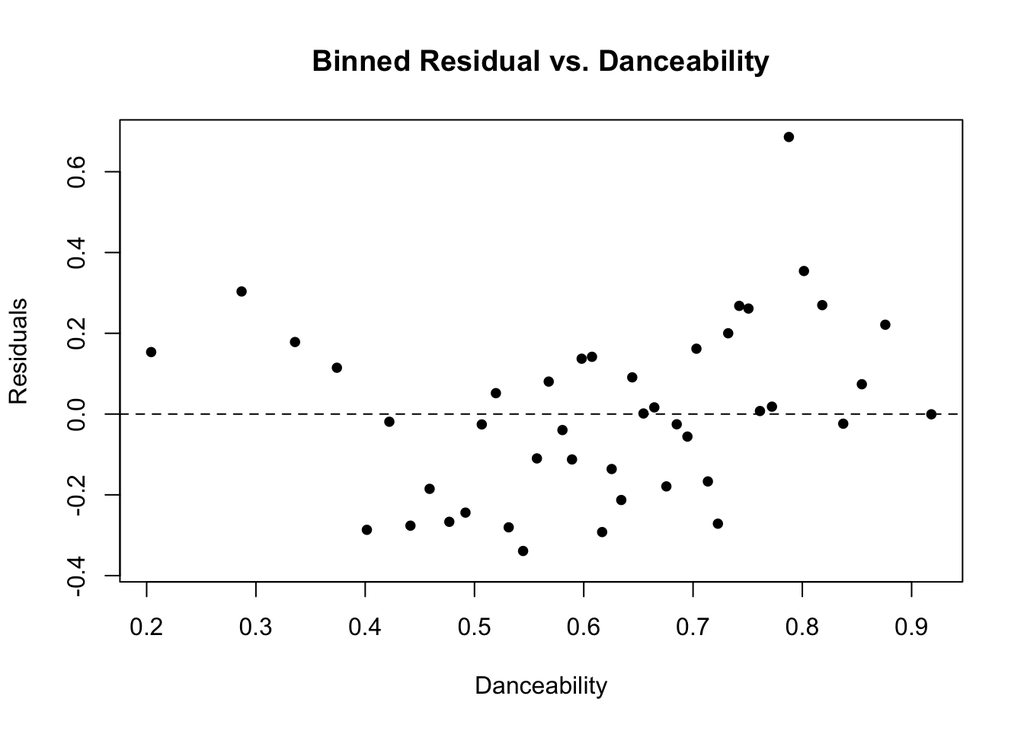

```r
arm::binnedplot(x = final_model$danceability, y = final_model$.resid,
                xlab = "Danceability",
                ylab = "Residuals",
                main = "Binned Residual vs. Danceability",
                col.int = FALSE)
```

# Exercise 8

```r
final_model %>%
  mutate(resid_key = if_else(.resid > 1 | .resid < -1, "high Residual", "low Residual")) %>%
  group_by(key, resid_key) %>%
  summarise(n = n()) %>%
  kable(format="markdown")
```

[output not shown]

| key | resid_key | n |
| --- | --- | --- |
| D | high Residual | 98 |
| D | low Residual | 86 |
| D# | high Residual | 21 |
| D# | low Residual | 42 |
| Other | high Residual | 1039 |
| Other | low Residual | 731 |

# Exercise 9

The plot in exercise 6 does not indicate a linear relationship between the fitted and predictor values. Therefore, I would say that the linearity assumption is not satisfied.

### Part 3: Model Assessment and Prediction

# Exercise 10

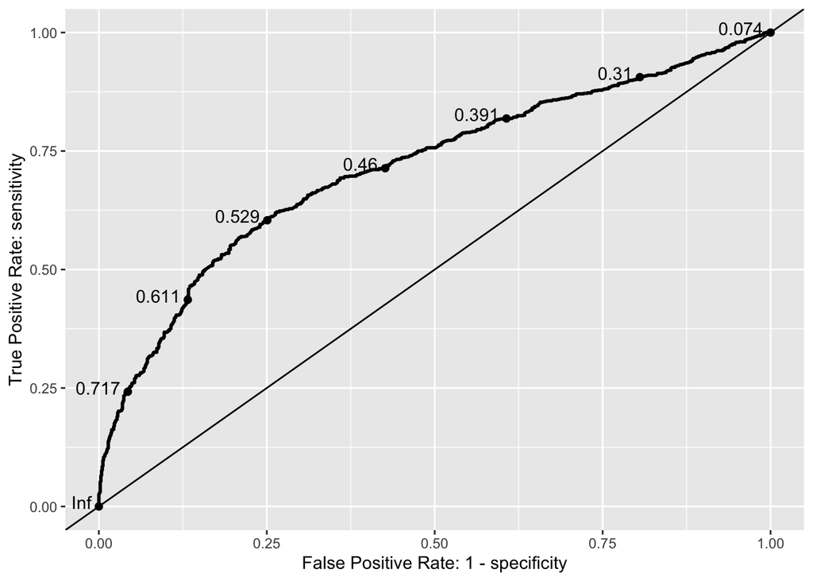

```r
roc_plot <- ggplot(final_model, aes(d = as.numeric(target), m = .fitted)) +
  geom_roc(n.cuts = 8, labelround = 3) +
  geom_abline(intercept = 0) +
  labs(x = "False Positive Rate: 1 - specificity",
       y = "True Positive Rate: sensitivity")
roc_plot
```

```r
calc_auc(roc_plot)$AUC
```

```
## [1] 0.7137869
```

# Exercise 11

# Exercise 12

I think a threshold of 0.58 would be best. This threshold value optimizes the true positive rate while maintaining a small false positive rate.

# Exercise 13

```r
threshold = 0.58
final_model %>%
  mutate(prediction = if_else(.fitted < threshold, "0:No","1:Yes")) %>%
  group_by(target, prediction) %>%
  summarise(n = n()) %>%
  kable(format="markdown")
```

| target | prediction | n |
| --- | --- | --- |
| 0 | 0:No | 836 |
| 0 | 1:Yes | 161 |
| 1 | 0:No | 508 |
| 1 | 1:Yes | 512 |

# Exercise 14